# Social Network

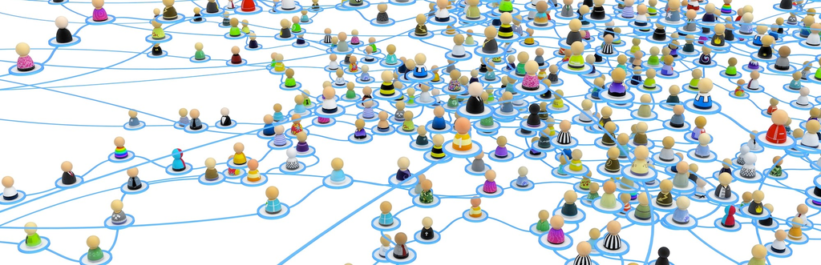

.................................................... document start ....................................................

## Synopsis

**Terms**

## Exposition

### Representation

#### Network Diagram

- Nodes
- Directed Links
- Undirected Links (bi-directional links)

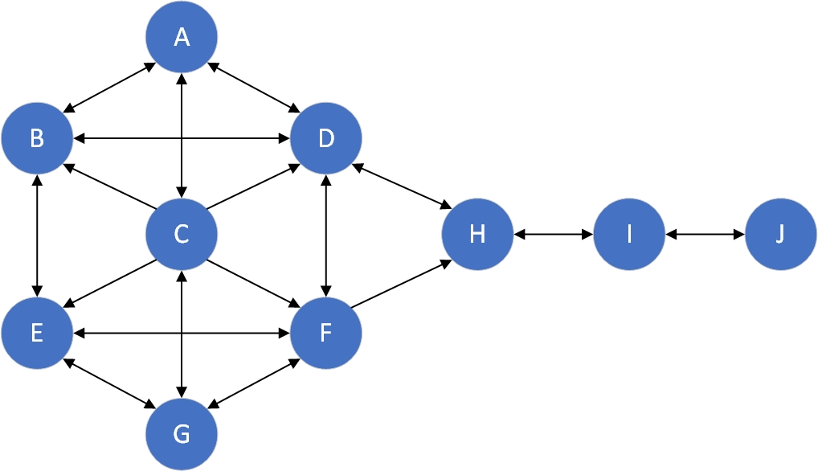

#### Adjacency Matrix

**data**

|  | A | B | C | D | E | F | G | H | I | J |
| --- | --- | --- | --- | --- | --- | --- | --- | --- | --- | --- |
| A | 0 | 1 | 1 | 1 | 0 | 0 | 0 | 0 | 0 | 0 |
| B | 1 | 0 | 0 | 1 | 1 | 0 | 0 | 0 | 0 | 0 |
| C | 1 | 1 | 0 | 1 | 1 | 1 | 1 | 0 | 0 | 0 |
| D | 1 | 1 | 0 | 0 | 0 | 1 | 0 | 1 | 0 | 0 |
| E | 0 | 1 | 0 | 0 | 0 | 1 | 1 | 0 | 0 | 0 |
| F | 0 | 0 | 0 | 1 | 1 | 0 | 1 | 1 | 0 | 0 |
| G | 0 | 0 | 1 | 0 | 1 | 1 | 0 | 0 | 0 | 0 |
| H | 0 | 0 | 0 | 1 | 0 | 0 | 0 | 0 | 1 | 0 |
| I | 0 | 0 | 0 | 0 | 0 | 0 | 0 | 1 | 0 | 1 |
| J | 0 | 0 | 0 | 0 | 0 | 0 | 0 | 0 | 1 | 0 |

#### Link List

**link list**

| A\|B | A\|C | A\|D | B\|A | B\|D | B\|E | C\|A | C\|B | C\|D | C\|E | C\|F | C\|G | D\|A | D\|B | D\|F | D\|H | E\|B | E\|F | E\|G | F\|D | F\|E | F\|G | F\|H | G\|C | G\|E | G\|F | H\|D | H\|I | I\|H | I\|J | … |
| --- | --- | --- | --- | --- | --- | --- | --- | --- | --- | --- | --- | --- | --- | --- | --- | --- | --- | --- | --- | --- | --- | --- | --- | --- | --- | --- | --- | --- | --- | --- |

### Descriptive Statistics for Social Network

#### Network-Level Statistics

- **Size** of a Social Network
  - number of links
- **Order** of a Social Network
  - number of nodes
- **Diameter** of Social Network
  - maximum of shortest path lengths
- **Average Path Length** of a Social Network
  - mean of shortest path lengths
- **Density** of a Social Network
  - fraction of possible links that are present
- **Giant Component Order** of a Social Network
  - largest set of connected nodes
  - strongly connected component: set of nodes that can reach each other by directed links
  - weakly connected component: set of nodes connected somehow

**network-level statistics**

| size | order | diameter | average_path_length | density | giant |
| --- | --- | --- | --- | --- | --- |
| 31 | 10 | 5 | 2.155556 | 0.3444444 | 10 |

#### Node-Level Statistics

**shortest path length**

|  | A | B | C | D | E | F | G | H | I | J |
| --- | --- | --- | --- | --- | --- | --- | --- | --- | --- | --- |
| A | 0 | 1 | 1 | 1 | 2 | 2 | 2 | 2 | 3 | 4 |
| B | 1 | 0 | 2 | 1 | 1 | 2 | 2 | 2 | 3 | 4 |
| C | 1 | 1 | 0 | 1 | 1 | 1 | 1 | 2 | 3 | 4 |
| D | 1 | 1 | 2 | 0 | 2 | 1 | 2 | 1 | 2 | 3 |
| E | 2 | 1 | 2 | 2 | 0 | 1 | 1 | 2 | 3 | 4 |
| F | 2 | 2 | 2 | 1 | 1 | 0 | 1 | 1 | 2 | 3 |
| G | 2 | 2 | 1 | 2 | 1 | 1 | 0 | 2 | 3 | 4 |
| H | 2 | 2 | 3 | 1 | 3 | 2 | 3 | 0 | 1 | 2 |
| I | 3 | 3 | 4 | 2 | 4 | 3 | 4 | 1 | 0 | 1 |
| J | 4 | 4 | 5 | 3 | 5 | 4 | 5 | 2 | 1 | 0 |

**node-level statistics**

|  | indegree | outdegree | betweenness | average_path_length | closeness | eccentricity | eigencentrality |
| --- | --- | --- | --- | --- | --- | --- | --- |
| A | 3 | 3 | 5.0 | 2.000000 | 0.0555556 | 4 | 0.6681605 |
| B | 4 | 3 | 4.0 | 1.888889 | 0.0555556 | 4 | 0.8520097 |
| C | 2 | 6 | 4.0 | 1.666667 | 0.0666667 | 4 | 0.3801319 |
| D | 5 | 4 | 28.0 | 1.555556 | 0.0666667 | 3 | 1.0000000 |
| E | 4 | 3 | 2.5 | 1.888889 | 0.0555556 | 4 | 0.7980391 |
| F | 4 | 4 | 14.5 | 1.555556 | 0.0666667 | 3 | 0.8321326 |
| G | 3 | 3 | 2.0 | 2.000000 | 0.0555556 | 4 | 0.6017564 |
| H | 3 | 2 | 28.0 | 1.666667 | 0.0526316 | 3 | 0.6082919 |
| I | 2 | 2 | 16.0 | 2.333333 | 0.0400000 | 4 | 0.2000045 |
| J | 1 | 1 | 0.0 | 3.222222 | 0.0303030 | 5 | 0.0598686 |

### More Descriptive Statistics for Social Network

#### Data

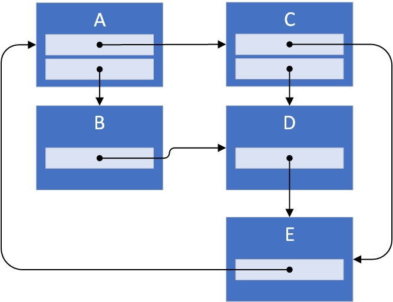

**data**

|  | A | B | C | D | E |
| --- | --- | --- | --- | --- | --- |
| A | 0 | 1 | 1 | 0 | 0 |
| B | 0 | 0 | 0 | 1 | 0 |
| C | 0 | 0 | 0 | 1 | 1 |
| D | 0 | 0 | 0 | 0 | 1 |
| E | 1 | 0 | 0 | 0 | 0 |

#### Expected Occurrence in a Random Walk

Approximates the probability of arriving at a node by randomly following many links.

**A random path of 20 steps:** C > E > A > B > D > E > A > C > E > A > B > D > E > A > B > D > E > A > C > D

**expected occurence**

| node | A | B | C | D | E |
| --- | --- | --- | --- | --- | --- |
| prob | 0.25 | 0.15 | 0.15 | 0.20 | 0.25 |

**A random path of 1000000 steps**

**expected occurence**

| node | A | B | C | D | E |
| --- | --- | --- | --- | --- | --- |
| prob | 0.266700 | 0.133292 | 0.133409 | 0.199899 | 0.266700 |

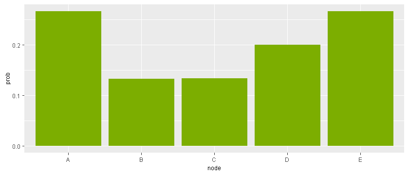

#### PageRank without Dampening

Approximates the probability of arriving at a node by randomly following many links.

##### Algorithm

Here is the algorithm to calculate the pageranks of nodes in a social network:

- For each node, initialize a pagerank. The pageranks can be equal or different from each other, but sum to one.
- Repeat several times ...
  - For each node, revise its pagerank to be the weighted sum of pageranks contributed by all nodes that link to it. The weight that goes with a certain node's contribution is based on how many links emit from that node.

Here is the calculation to revise a pagerank:

$ pagerank_i \leftarrow \sum_{j \, \in \, C(i)} \frac{pagerank_j}{L(j)} $

where ...

- $pagerank_i$ is the pagerank of the $i^{th}$ node
- $pagerank_j$ is the pagerank of the $j^{th}$ node
- $C(i)$ is the set of nodes that link to the $i^{th}$ node
- $L(j)$ is the outdegree of the $j^{th}$ node
- $N$ is the number of nodes (order)

##### Initialize

**data**

|  | A | B | C | D | E |
| --- | --- | --- | --- | --- | --- |
| A | 0 | 1 | 1 | 0 | 0 |
| B | 0 | 0 | 0 | 1 | 0 |
| C | 0 | 0 | 0 | 1 | 1 |
| D | 0 | 0 | 0 | 0 | 1 |
| E | 1 | 0 | 0 | 0 | 0 |

**outdegree**

|  | outdegree |
| --- | --- |
| A | 2 |
| B | 1 |
| C | 2 |
| D | 1 |
| E | 1 |

**share**

|  | A | B | C | D | E |
| --- | --- | --- | --- | --- | --- |
| A | 0 | 0.5 | 0.5 | 0.0 | 0.0 |
| B | 0 | 0.0 | 0.0 | 1.0 | 0.0 |
| C | 0 | 0.0 | 0.0 | 0.5 | 0.5 |
| D | 0 | 0.0 | 0.0 | 0.0 | 1.0 |
| E | 1 | 0.0 | 0.0 | 0.0 | 0.0 |

**pagerank**

|  | pagerank.0 |
| --- | --- |
| A | 0.2 |
| B | 0.2 |
| C | 0.2 |
| D | 0.2 |
| E | 0.2 |

##### Iterate

**Iteration 1:**

**data**

|  | A | B | C | D | E |
| --- | --- | --- | --- | --- | --- |
| A | 0 | 1 | 1 | 0 | 0 |
| B | 0 | 0 | 0 | 1 | 0 |
| C | 0 | 0 | 0 | 1 | 1 |
| D | 0 | 0 | 0 | 0 | 1 |
| E | 1 | 0 | 0 | 0 | 0 |

**share**

|  | A | B | C | D | E |
| --- | --- | --- | --- | --- | --- |
| A | 0 | 0.5 | 0.5 | 0.0 | 0.0 |
| B | 0 | 0.0 | 0.0 | 1.0 | 0.0 |
| C | 0 | 0.0 | 0.0 | 0.5 | 0.5 |
| D | 0 | 0.0 | 0.0 | 0.0 | 1.0 |
| E | 1 | 0.0 | 0.0 | 0.0 | 0.0 |

**pagerank.old**

|  | pagerank.old |
| --- | --- |
| A | 0.2 |
| B | 0.2 |
| C | 0.2 |
| D | 0.2 |
| E | 0.2 |

**pagerank.new**

|  | pagerank |
| --- | --- |
| A | 0.2 |
| B | 0.1 |
| C | 0.1 |
| D | 0.3 |
| E | 0.3 |

**Iteration 2:**

**data**

|  | A | B | C | D | E |
| --- | --- | --- | --- | --- | --- |
| A | 0 | 1 | 1 | 0 | 0 |
| B | 0 | 0 | 0 | 1 | 0 |
| C | 0 | 0 | 0 | 1 | 1 |
| D | 0 | 0 | 0 | 0 | 1 |
| E | 1 | 0 | 0 | 0 | 0 |

**share**

|  | A | B | C | D | E |
| --- | --- | --- | --- | --- | --- |
| A | 0 | 0.5 | 0.5 | 0.0 | 0.0 |
| B | 0 | 0.0 | 0.0 | 1.0 | 0.0 |
| C | 0 | 0.0 | 0.0 | 0.5 | 0.5 |
| D | 0 | 0.0 | 0.0 | 0.0 | 1.0 |
| E | 1 | 0.0 | 0.0 | 0.0 | 0.0 |

**pagerank.old**

|  | pagerank.old |
| --- | --- |
| A | 0.2 |
| B | 0.1 |
| C | 0.1 |
| D | 0.3 |
| E | 0.3 |

**pagerank.new**

|  | pagerank |
| --- | --- |
| A | 0.30 |
| B | 0.10 |
| C | 0.10 |
| D | 0.15 |
| E | 0.35 |

**Iteration 100:**

**data**

|  | A | B | C | D | E |
| --- | --- | --- | --- | --- | --- |
| A | 0 | 1 | 1 | 0 | 0 |
| B | 0 | 0 | 0 | 1 | 0 |
| C | 0 | 0 | 0 | 1 | 1 |
| D | 0 | 0 | 0 | 0 | 1 |
| E | 1 | 0 | 0 | 0 | 0 |

**pagerank**

|  | pagerank |
| --- | --- |
| A | 0.2665276 |
| B | 0.1333174 |
| C | 0.1333174 |
| D | 0.2001229 |
| E | 0.2667146 |

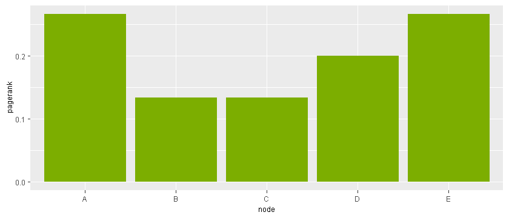

#### PageRank with Dampening

Approximates the probability of arriving at a node by randomly following links occasionally transporting to a new node.

##### Algorithm

Here is the algorithm to calculate the pageranks of nodes in a social network:

- For each node, initialize a pagerank. The pageranks can be equal or different from each other, but sum to one.
- Repeat several times ...
  - For each node, revise its pagerank to be the weighted sum of pageranks contributed by all nodes that link to it. The weight that goes with a certain node's contribution is based on how many links emit from that node.

Here is the calculation to revise a pagerank:

$ pagerank_i \leftarrow d \big( \sum_{j \, \in \, C(i)} \frac{pagerank_j}{L(j)} \big) + \frac{1-d}{N} $

where ...

- $pagerank_i$ is the pagerank of the $i^{th}$ node
- $pagerank_j$ is the pagerank of the $j^{th}$ node
- $d$ is a dampening factor ($0 \leq d \leq 1$)
- $C(i)$ is the set of nodes that link to the $i^{th}$ node
- $L(j)$ is the outdegree of the $j^{th}$ node
- $N$ is the number of nodes (order)

##### Initialize

**data**

|  | A | B | C | D | E |
| --- | --- | --- | --- | --- | --- |
| A | 0 | 1 | 1 | 0 | 0 |
| B | 0 | 0 | 0 | 1 | 0 |
| C | 0 | 0 | 0 | 1 | 1 |
| D | 0 | 0 | 0 | 0 | 1 |
| E | 1 | 0 | 0 | 0 | 0 |

**outdegree**

|  | outdegree |
| --- | --- |
| A | 2 |
| B | 1 |
| C | 2 |
| D | 1 |
| E | 1 |

**share**

|  | A | B | C | D | E |
| --- | --- | --- | --- | --- | --- |
| A | 0 | 0.5 | 0.5 | 0.0 | 0.0 |
| B | 0 | 0.0 | 0.0 | 1.0 | 0.0 |
| C | 0 | 0.0 | 0.0 | 0.5 | 0.5 |
| D | 0 | 0.0 | 0.0 | 0.0 | 1.0 |
| E | 1 | 0.0 | 0.0 | 0.0 | 0.0 |

**pagerank**

|  | pagerank.0 |
| --- | --- |
| A | 0.2 |
| B | 0.2 |
| C | 0.2 |
| D | 0.2 |
| E | 0.2 |

##### Iterate

**Iteration 1:**

**data**

|  | A | B | C | D | E |
| --- | --- | --- | --- | --- | --- |
| A | 0 | 1 | 1 | 0 | 0 |
| B | 0 | 0 | 0 | 1 | 0 |
| C | 0 | 0 | 0 | 1 | 1 |
| D | 0 | 0 | 0 | 0 | 1 |
| E | 1 | 0 | 0 | 0 | 0 |

**share**

|  | A | B | C | D | E |
| --- | --- | --- | --- | --- | --- |
| A | 0 | 0.5 | 0.5 | 0.0 | 0.0 |
| B | 0 | 0.0 | 0.0 | 1.0 | 0.0 |
| C | 0 | 0.0 | 0.0 | 0.5 | 0.5 |
| D | 0 | 0.0 | 0.0 | 0.0 | 1.0 |
| E | 1 | 0.0 | 0.0 | 0.0 | 0.0 |

**pagerank.old**

|  | pagerank.old |
| --- | --- |
| A | 0.2 |
| B | 0.2 |
| C | 0.2 |
| D | 0.2 |
| E | 0.2 |

**damp_factor**

| damp |
| --- |
| 0.85 |

**pagerank.new**

|  | pagerank |
| --- | --- |
| A | 0.200 |
| B | 0.115 |
| C | 0.115 |
| D | 0.285 |
| E | 0.285 |

**Iteration 2:**

**data**

|  | A | B | C | D | E |
| --- | --- | --- | --- | --- | --- |
| A | 0 | 1 | 1 | 0 | 0 |
| B | 0 | 0 | 0 | 1 | 0 |
| C | 0 | 0 | 0 | 1 | 1 |
| D | 0 | 0 | 0 | 0 | 1 |
| E | 1 | 0 | 0 | 0 | 0 |

**share**

|  | A | B | C | D | E |
| --- | --- | --- | --- | --- | --- |
| A | 0 | 0.5 | 0.5 | 0.0 | 0.0 |
| B | 0 | 0.0 | 0.0 | 1.0 | 0.0 |
| C | 0 | 0.0 | 0.0 | 0.5 | 0.5 |
| D | 0 | 0.0 | 0.0 | 0.0 | 1.0 |
| E | 1 | 0.0 | 0.0 | 0.0 | 0.0 |

**pagerank.old**

|  | pagerank.old |
| --- | --- |
| A | 0.200 |
| B | 0.115 |
| C | 0.115 |
| D | 0.285 |
| E | 0.285 |

**damp_factor**

| damp |
| --- |
| 0.85 |

**pagerank.new**

|  | pagerank |
| --- | --- |
| A | 0.272250 |
| B | 0.115000 |
| C | 0.115000 |
| D | 0.176625 |
| E | 0.321125 |

**Iteration 100:**

**data**

|  | A | B | C | D | E |
| --- | --- | --- | --- | --- | --- |
| A | 0 | 1 | 1 | 0 | 0 |
| B | 0 | 0 | 0 | 1 | 0 |
| C | 0 | 0 | 0 | 1 | 1 |
| D | 0 | 0 | 0 | 0 | 1 |
| E | 1 | 0 | 0 | 0 | 0 |

**pagerank**

|  | pagerank |
| --- | --- |
| A | 0.2541918 |
| B | 0.1380315 |
| C | 0.1380315 |
| D | 0.2059902 |
| E | 0.2637550 |

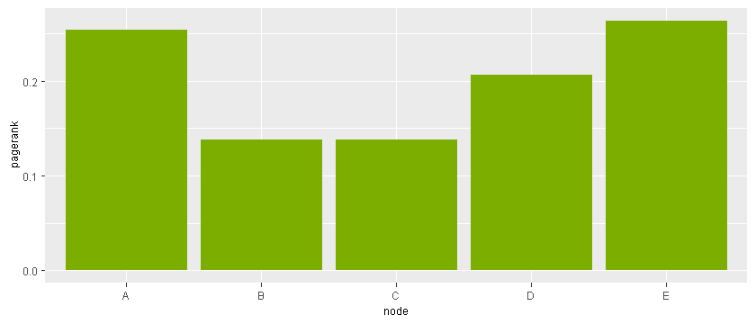

Copyright (c) Berkeley Data Analytics Group, LLC Document revised November 15, 2019